# Image Database

## 4.3 Viewing Individual Samples

The shape analysis from a single sample can easily be brought up and rendered in the browser.

```sql
SELECT lacuna_points FROM GenomicCellAnalysis WHERE strain == "B6" & gender == "female" LIMIT 1
```

[interactive chart not shown]

A number of further analyses can be made in both 2D and 3D plots looking at everything from cell size and shape to density.

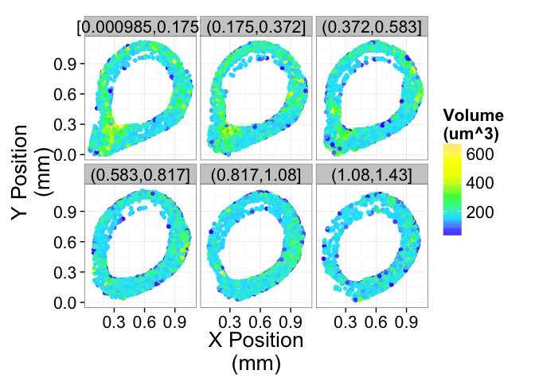

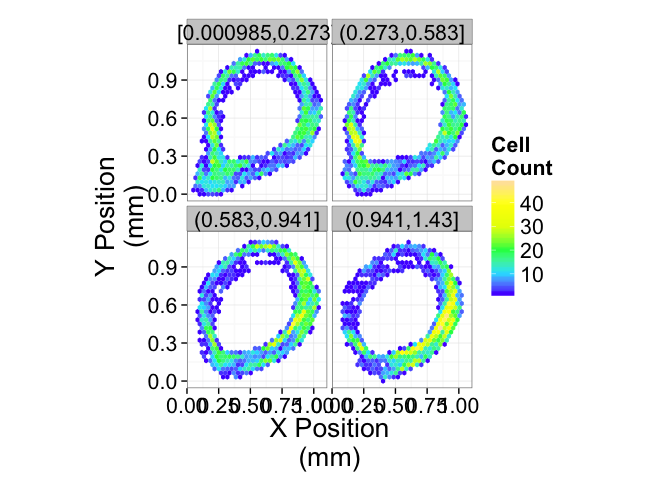

```sql
SELECT lacuna_points FROM CellAnalysis WHERE strain == "C3H" & gender == "female" LIMIT 1
```

[interactive chart not shown]

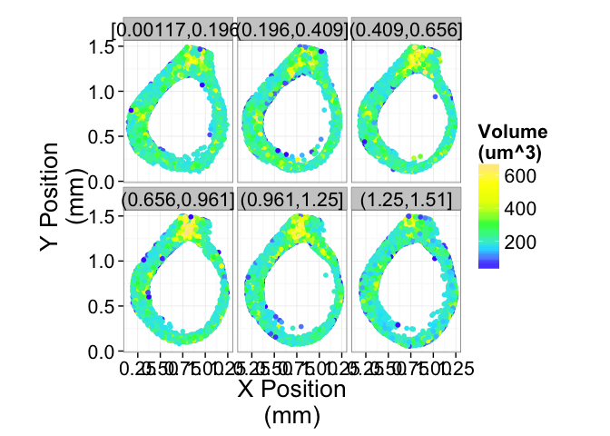

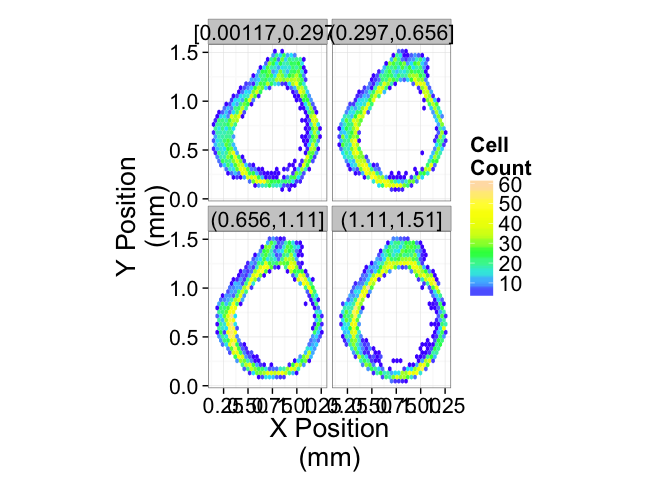

## 4.4 Compare two datasets directly

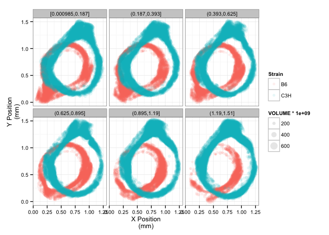

```scala
{
  sql("SELECT lacuna_points FROM GenomicCellAnalysis WHERE strain == 'B6' & gender == 'female'")
  ++
  sql("SELECT lacuna_points FROM GenomicCellAnalysis WHERE strain == 'C3H' & gender == 'female')
}.groupBy("strain").show
```

## 4.5 Run Standard Analyses over millions of cells

Instead of storing the results in tables for each sample, have each of the cells as a row in a new table in the database called *AllLacunae* (this time with 50+ million rows)

```scala
GenomicCellAnalysis.flattenDF().registerTempTable("AllLacunae")
```

We can now run SQL commands and get results instantly even though it would take minutes to hours on a standard MySQL instance.

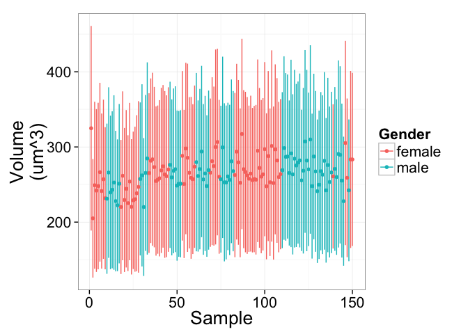

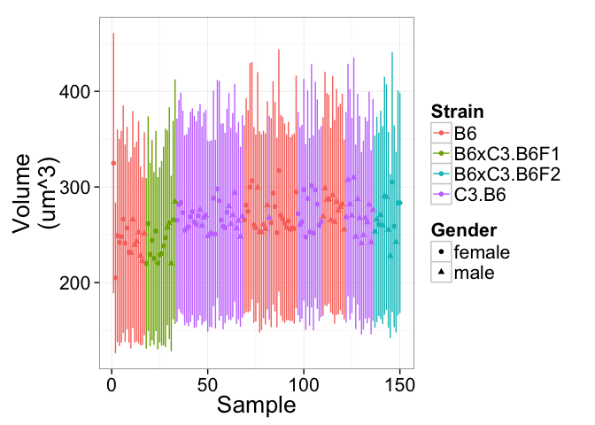

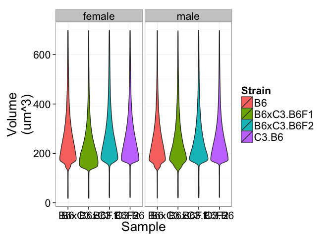

```sql
SELECT AVG(VOLUME),SD(VOLUME) FROM GenomicCellAnalysis GROUP BY boneId
```

# 5 Acknowledgements

Analysis powered by IJSQL and Spark Image Layer from 4Quant, Visualizations, and Document Generation provided by:

To cite ggplot2 in publications, please use:

H. Wickham. ggplot2: elegant graphics for data analysis. Springer New York, 2009.

A BibTeX entry for LaTeX users is

@Book{, author = {Hadley Wickham}, title = {ggplot2: elegant graphics for data analysis}, publisher = {Springer New York}, year = {2009}, isbn = {978-0-387-98140-6}, url = {http://had.co.nz/ggplot2/book}, }

To cite package ‘threejs’ in publications use:

B. W. Lewis (2015). threejs: 3D Graphics using Three.js and Htmlwidgets. R package version 0.2.1. http://bwlewis.github.io/rthreejs

A BibTeX entry for LaTeX users is

@Manual{, title = {threejs: 3D Graphics using Three.js and Htmlwidgets}, author = {B. W. Lewis}, year = {2015}, note = {R package version 0.2.1}, url = {http://bwlewis.github.io/rthreejs}, }

ATTENTION: This citation information has been auto-generated from the package DESCRIPTION file and may need manual editing, see ‘help(“citation”)’.

To cite plyr in publications use:

Hadley Wickham (2011). The Split-Apply-Combine Strategy for Data Analysis. Journal of Statistical Software, 40(1), 1-29. URL http://www.jstatsoft.org/v40/i01/.

A BibTeX entry for LaTeX users is

@Article{, title = {The Split-Apply-Combine Strategy for Data Analysis}, author = {Hadley Wickham}, journal = {Journal of Statistical Software}, year = {2011}, volume = {40}, number = {1}, pages = {1–29}, url = {http://www.jstatsoft.org/v40/i01/}, }

To cite package ‘rmarkdown’ in publications use:

JJ Allaire, Joe Cheng, Yihui Xie, Jonathan McPherson, Winston Chang, Jeff Allen, Hadley Wickham and Rob Hyndman (2015). rmarkdown: Dynamic Documents for R. R package version 0.5.1. http://CRAN.R-project.org/package=rmarkdown

A BibTeX entry for LaTeX users is

@Manual{, title = {rmarkdown: Dynamic Documents for R}, author = {JJ Allaire and Joe Cheng and Yihui Xie and Jonathan McPherson and Winston Chang and Jeff Allen and Hadley Wickham and Rob Hyndman}, year = {2015}, note = {R package version 0.5.1}, url = {http://CRAN.R-project.org/package=rmarkdown}, }

To cite the ‘knitr’ package in publications use:

Yihui Xie (2015). knitr: A General-Purpose Package for Dynamic Report Generation in R. R package version 1.10.

Yihui Xie (2013) Dynamic Documents with R and knitr. Chapman and Hall/CRC. ISBN 978-1482203530

Yihui Xie (2014) knitr: A Comprehensive Tool for Reproducible Research in R. In Victoria Stodden, Friedrich Leisch and Roger D. Peng, editors, Implementing Reproducible Computational Research. Chapman and Hall/CRC. ISBN 978-1466561595